# Puzzle

Bob Anderson

20/01/2021

```r
library(tidyverse)
library(data.table) # database/sql-like syntax for doing stuff with data frames very fast
library(here) # relative paths within this project. Useful for data loading
library(flextable)
```

## The Objective

I am preparing for this year’s grand analysis of the 20 years of meadow data. P has been advised by her friends that she should stop looking at species distributions and look instead at the distributions for components of traits which the species display. The aim, at a first approximation, is to model and test the abundances by trait against environmental data ( weather data). I can do the analysis and work the modelling. What is painful is assembling the basic tables to be used.

## Assembling the data

There are 3 data tables providing input data: thfSpp, thfTraits, thFEnv. The optimal outcome would be to run the whole process in a set of nested loops, but I have been unable to make that work. Instead, I have broken the process into the following steps

### Step 1

Creates a temporary df holding the trait and species abundances. The trait chosen is arbitary.

```r
# wkDT <- t(thfSpp) # where did this come from? Which dataset?
# wkDT <- wkDT[-1, ]
# wkDT <- cbind.data.frame(wkDT, thfTraits$h_max)
# colnames(wkDT) <- c("obs1", "obs2", "obs3", "obs4", "obs5", "obs6", "obs7", "obs8", "obs9", "obs10", "obs11", "obs12", "obs13", "h_max")

# load the data
# stored in data folder in this project for now
# from here on we are using data.table (which is not always obvious from the code)
thfSppDT <- data.table::fread(here::here("data", "thfSpp.csv"))
thfTraitsDT <- data.table::fread(here::here("data", "thfTraits.csv"))

# now I'm stuck - I can't see what you trying to do next but
# on the assumption that we need to link the counts to the traits by species we can:
# convert the count data into a long form so we can attach the trait data to each species observation

thfSppDT_l <- data.table::melt(thfSppDT, id.vars = c("year"),
                               variable.name = "spp",
                               value.name = "count")
head(thfSppDT_l)
```

```
##    year       spp count
## 1: 2004 Agro.capi    25
## 2: 2005 Agro.capi     0
## 3: 2006 Agro.capi     0
## 4: 2007 Agro.capi    35
## 5: 2008 Agro.capi    25
## 6: 2009 Agro.capi     0
```

```r
# now merge the two datasets so we add the trait record to each of the
# count records. This would be better done on the fly to save memory but
# for now...

data.table::setkey(thfSppDT_l, spp) # set the variable to match on
data.table::setkey(thfTraitsDT, spp) # set the variable to match on

mergedDT <- thfSppDT_l[thfTraitsDT]

head(mergedDT)
```

```
##    year       spp count h_max h_min le_area   le_long ell_N strategy
## 1: 2004 Agro.capi    25    70    10     5.5 evergreen     4      csr
## 2: 2005 Agro.capi     0    70    10     5.5 evergreen     4      csr
## 3: 2006 Agro.capi     0    70    10     5.5 evergreen     4      csr
## 4: 2007 Agro.capi    35    70    10     5.5 evergreen     4      csr
## 5: 2008 Agro.capi    25    70    10     5.5 evergreen     4      csr
## 6: 2009 Agro.capi     0    70    10     5.5 evergreen     4      csr
```

```r
table(mergedDT$year, useNA = "always")
```

```
##
## 2004 2005 2006 2007 2008 2009 2010 2011 2012 2013 2014 2015 2016 <NA>
##   31   31   31   31   31   31   31   31   31   31   31   31   31    1
```

```r
# we get an NA due to merge
mergedDT <- mergedDT[!is.na(year)] # filter it out
table(mergedDT$year, useNA = "always")
```

```
##
## 2004 2005 2006 2007 2008 2009 2010 2011 2012 2013 2014 2015 2016 <NA>
##   31   31   31   31   31   31   31   31   31   31   31   31   31    0
```

### Step 2

To create the trait df, take the wkDT and group the data by the trait and for obs1 summarise abundances for components .

```r
# h_maxDT <- wkDT %>%
#   group_by(h_max) #%>%
#   summarise(tot = sum(obs1))

# like this? (I'm not sure what obs1 is - years?)

h_max <- mergedDT[, .(sum = sum(count)),
                     keyby = .(year, h_max)]
h_max
```

```
##      year h_max  sum
##   1: 2004    30   94
##   2: 2004    35   65
##   3: 2004    40  760
##   4: 2004    50  207
##   5: 2004    60  478
##  ---
## 152: 2016    80   52
## 153: 2016    90    0
## 154: 2016   100 1173
## 155: 2016   120    0
## 156: 2016   150   14
```

```r
# more generically, if we convert this table to a  long form we can use data.table magic

lDT <- data.table::melt(mergedDT, id.vars = c("year", "spp", "count"),
                        variable.name = "trait")
head(lDT)
```

```
##    year       spp count trait value
## 1: 2004 Agro.capi    25 h_max    70
## 2: 2005 Agro.capi     0 h_max    70
## 3: 2006 Agro.capi     0 h_max    70
## 4: 2007 Agro.capi    35 h_max    70
## 5: 2008 Agro.capi    25 h_max    70
## 6: 2009 Agro.capi     0 h_max    70
```

```r
# now sum the counts by trait-value by year
# no loops needed :-)
traitTable <- lDT[,
                  .(sumOfCounts = sum(count)),
                  keyby = .(year, trait, value)]

head(traitTable)
```

```
##    year trait value sumOfCounts
## 1: 2004 h_max   100         854
## 2: 2004 h_max   120          10
## 3: 2004 h_max   150           0
## 4: 2004 h_max    30          94
## 5: 2004 h_max    35          65
## 6: 2004 h_max    40         760
```

```r
# traitTable now holds a sum of counts by trait-value by year
# is that what you want?

# you can then turn it back round to wide data if you want but probably easier to keep it like this
```

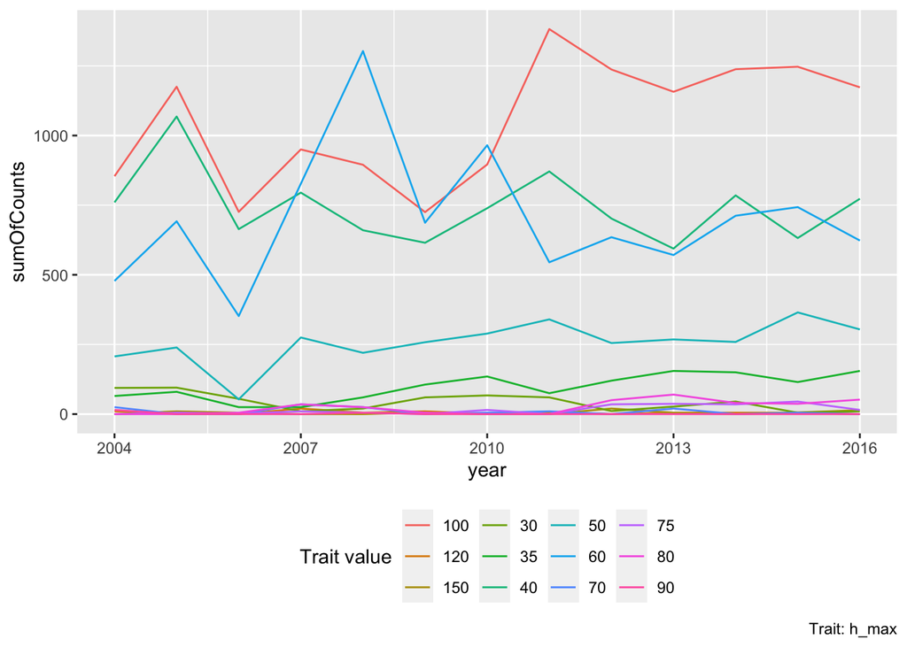

h_max trends

```r
ggplot2::ggplot(traitTable[trait == "h_max"],
                aes(x = year,
                    y = sumOfCounts,
                    colour = value)) +
  geom_line() +
  scale_color_discrete(name = "Trait value") +
  theme(legend.position="bottom", ) +
  labs(caption = "Trait: h_max")
```

So now if you want to do something with the h_max trait you just extract the relevant rows like this:

```r
t <- traitTable[trait == "h_max"]
setkey(t, year, value)
flextable(t)
```

| year | trait | value | sumOfCounts |
| --- | --- | --- | --- |
| 2004 | h_max | 100 | 854 |
| 2004 | h_max | 120 | 10 |
| 2004 | h_max | 150 | 0 |
| 2004 | h_max | 30 | 94 |
| 2004 | h_max | 35 | 65 |
| 2004 | h_max | 40 | 760 |
| 2004 | h_max | 50 | 207 |
| 2004 | h_max | 60 | 478 |
| 2004 | h_max | 70 | 25 |
| 2004 | h_max | 75 | 0 |
| 2004 | h_max | 80 | 0 |
| 2004 | h_max | 90 | 15 |
| 2005 | h_max | 100 | 1175 |
| 2005 | h_max | 120 | 5 |
| 2005 | h_max | 150 | 10 |
| 2005 | h_max | 30 | 95 |
| 2005 | h_max | 35 | 80 |
| 2005 | h_max | 40 | 1068 |
| 2005 | h_max | 50 | 239 |
| 2005 | h_max | 60 | 692 |
| 2005 | h_max | 70 | 0 |
| 2005 | h_max | 75 | 5 |
| 2005 | h_max | 80 | 0 |
| 2005 | h_max | 90 | 0 |
| 2006 | h_max | 100 | 726 |
| 2006 | h_max | 120 | 0 |
| 2006 | h_max | 150 | 5 |
| 2006 | h_max | 30 | 55 |
| 2006 | h_max | 35 | 25 |
| 2006 | h_max | 40 | 664 |

[output cut: 126 more lines]

### Step 3

Now, by hand, run over obs2:obs13 aggregating the trait df.

```r
# tot <- wkDT  %>%
#   group_by(h_max) %>%
#   summarise(tot = sum(obs13))
#   h_maxDT<- cbind(h_maxDT, tot[,-1])
```

This gets me a df for the trait which I can save for re-use. I then repeat the exercise for the rest of the traits

## The Required Function

What I absolutely need is a function to do steps 2 and 3 automatically. P’s species list is going to give me 30+ cols of observations. Additionally, I could do with a function to build the trait data frames automatically into which steps 2 & 3 could insert the summaries. At present the traiit list looks to be 20 or so items long. Ideally, I could do with both functions bundled together as nested loops. What don’t want to do is spend loads of time just assembling the data. All the methods I have tried (loops, purr::map, lappy….vapply and more) all fail, hence my cry for help!